# R Notebook

```r
library(tidyverse)
```

# Question 1

## Take the data in the dataset qb_revenue_breakdown and make a stacked bar chart showing the sources of revenue across the two years in the dataset.

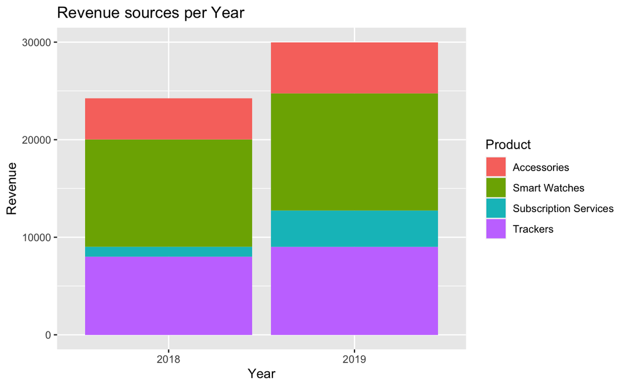

# Question 2

## Make a line chart showing monthly sales of the “flagship product” - the ‘KwikBit Unit 1’ - over the last year. This data is inside qb_monthly_sales, but you will need to use filter() or subset() (base R).

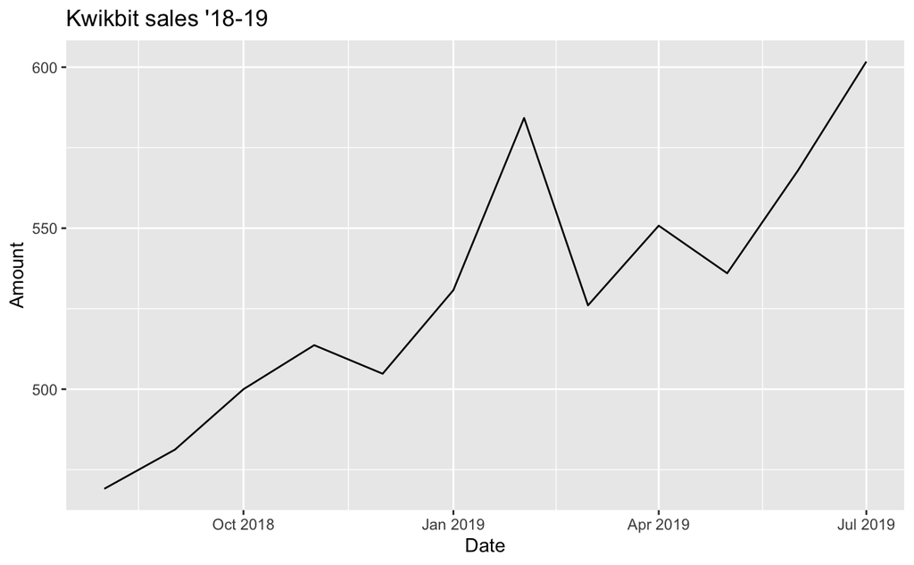

# Question 3

## Make a line chart showing monthly revenue and costs over the last year. This data is also in qb_monthly_sales.

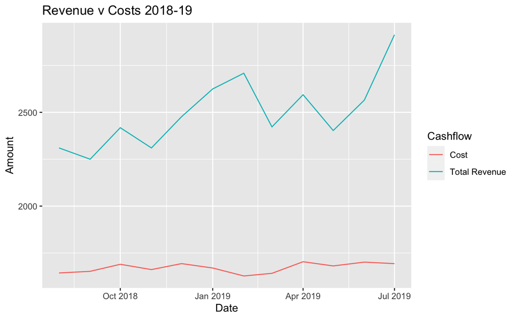

# Question 4

## Show annual sales of personal fitness trackers over the last 5 years broken down by company as a ribbon plot (use geom_area). This data is in qb_competitors.

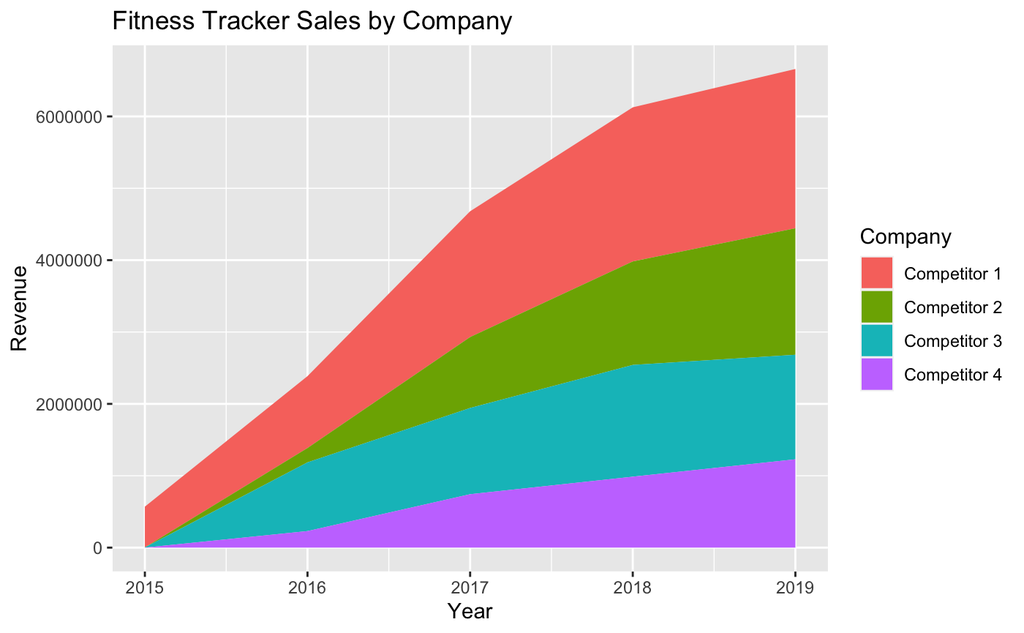

# Question 5

## Now show the sales from the four competitors as a line graph. Include an extra layer that shows the data points used to make the lines.

[output not shown]

[output cut: 33 more lines]

[output not shown]

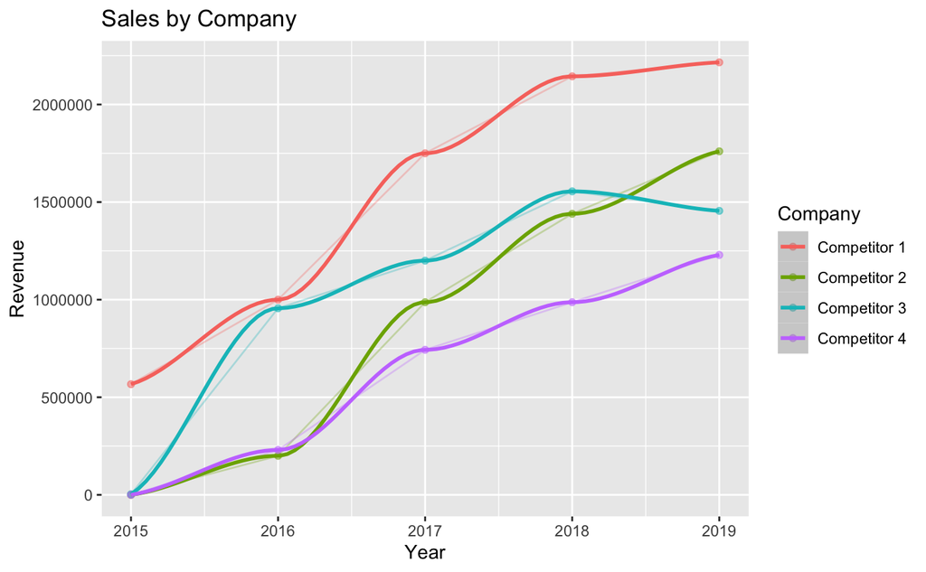

```r
ggplot(fitness_trackers)+
  geom_line(aes(x = Year, y = Revenue, colour = Company), alpha = 0.3) +
  geom_point(aes(x = Year, y = Revenue, colour = Company), alpha = 0.5) +
  geom_smooth(aes(x = Year, y = Revenue, colour = Company)) +
  labs(title = "Sales by Company")
```

# Question 6

## Now the company wants to compare the number of steps that their device counts vs. their competitors. Make a line graph of the number of steps throughout time, and use faceting to compare between companies and people. The data for this is in qb_device_data.

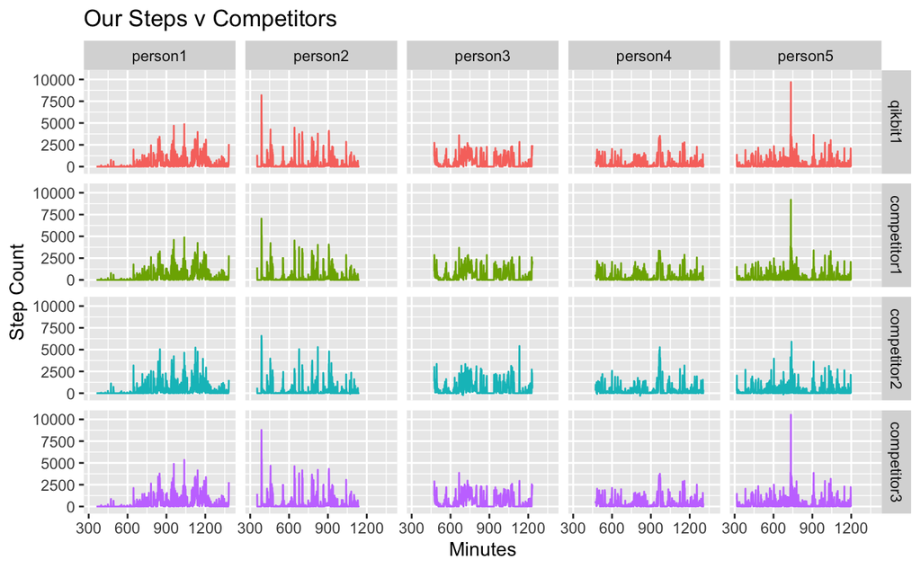